# aqi

# 1. 问题

对该数据集，有以下问题需要解答：

# 2. 导入包

```r
library(tidyverse) # 数据分析包
library(readxl) # 读取excel文件
library(psych) # 查看描述统计量
library(Hmisc)
library(pastecs)
library(knitr)
library(magrittr)
```

# 3. 导入数据

```r
aqi <- read_xlsx("空气质量指数.xlsx")
head(aqi)
```

| 城市 | 地区 | 城市AQI | PM2.5浓度 | PM10浓度 | 首要污染物 | 污染等级 | 地区AQI |
| --- | --- | --- | --- | --- | --- | --- | --- |
| 鞍山实时空气质量指数 | 明达新区 | 177 | 125μg/m³ | 228μg/m³ | PM2.5 | 轻度污染 | 165 |
| 鞍山实时空气质量指数 | 千山 | 177 | 117μg/m³ | 145μg/m³ | PM2.5 | 轻度污染 | 153 |
| 鞍山实时空气质量指数 | 深沟寺 | 177 | 138μg/m³ | 244μg/m³ | PM2.5 | 轻度污染 | 183 |
| 鞍山实时空气质量指数 | 太平 | 177 | 126μg/m³ | 239μg/m³ | PM2.5 | 轻度污染 | 166 |
| 鞍山实时空气质量指数 | 太阳城 | 177 | 142μg/m³ | 242μg/m³ | PM2.5 | 轻度污染 | 189 |
| 鞍山实时空气质量指数 | 铁西工业园区 | 177 | 156μg/m³ | 324μg/m³ | PM2.5 | 中度污染 | 206 |

# 4. 数据清洗

- 将变量中的冗余字符去掉

```r
aqi$城市 <- str_replace_all(aqi$城市, "[实时空气质量指数]", "") # 只保留城市名
aqi$PM2.5浓度 <- str_replace_all(aqi$PM2.5浓度, "[μg/m³|—μg/m³]", "") # 将单位去掉，只保留数值
aqi$PM10浓度 <- str_replace_all(aqi$PM10浓度, "[μg/m³|—μg/m³]", "")
aqi$首要污染物 <- str_replace_all(aqi$首要污染物, "[—]", "NA")
```

- 转换变量的数据类型，以便进行更好地进行计算

```r
aqi$城市AQI <- parse_double(aqi$城市AQI, na = "NA") # 转换为浮点类型

aqi$PM2.5浓度 <- parse_number(aqi$PM2.5浓度, na = "NA") # 转换为数值类型
aqi$PM10浓度 <- parse_number(aqi$PM10浓度, na = "NA")

aqi$首要污染物 <- parse_factor(aqi$首要污染物, na = "NA") # 转换为因子
level <- c("优", "良", "轻度污染", "中度污染", "严重污染")
aqi$污染等级 <- parse_factor(aqi$污染等级, levels = level, na = "NA")
```

- 简化变量名

```r
aqi <- rename(aqi, PM2.5 = PM2.5浓度, PM10 = PM10浓度)
```

```r
# 输出头6行数据
head(aqi)
```

| 城市 | 地区 | 城市AQI | PM2.5 | PM10 | 首要污染物 | 污染等级 | 地区AQI |
| --- | --- | --- | --- | --- | --- | --- | --- |
| 鞍山 | 明达新区 | 177 | 125 | 228 | PM2.5 | 轻度污染 | 165 |
| 鞍山 | 千山 | 177 | 117 | 145 | PM2.5 | 轻度污染 | 153 |
| 鞍山 | 深沟寺 | 177 | 138 | 244 | PM2.5 | 轻度污染 | 183 |
| 鞍山 | 太平 | 177 | 126 | 239 | PM2.5 | 轻度污染 | 166 |
| 鞍山 | 太阳城 | 177 | 142 | 242 | PM2.5 | 轻度污染 | 189 |
| 鞍山 | 铁西工业园区 | 177 | 156 | 324 | PM2.5 | 中度污染 | 206 |

# 5. 探索性数据分析

## 5.1 查看描述统计量

```r
stat.desc(aqi)
```

|  | 城市 | 地区 | 城市AQI | PM2.5 | PM10 | 首要污染物 | 污染等级 | 地区AQI |
| --- | --- | --- | --- | --- | --- | --- | --- | --- |
| nbr.val | NA | NA | 1.453000e+03 | 1.453000e+03 | 1.389000e+03 | NA | NA | 1.453000e+03 |
| nbr.null | NA | NA | 0.000000e+00 | 0.000000e+00 | 0.000000e+00 | NA | NA | 0.000000e+00 |
| nbr.na | NA | NA | 0.000000e+00 | 0.000000e+00 | 6.400000e+01 | NA | NA | 0.000000e+00 |
| min | NA | NA | 2.600000e+01 | 1.000000e+00 | 1.000000e+00 | NA | NA | 1.100000e+01 |
| max | NA | NA | 5.000000e+02 | 4.760000e+02 | 1.135000e+03 | NA | NA | 5.000000e+02 |
| range | NA | NA | 4.740000e+02 | 4.750000e+02 | 1.134000e+03 | NA | NA | 4.890000e+02 |
| sum | NA | NA | 1.242730e+05 | 8.403500e+04 | 1.360510e+05 | NA | NA | 1.248190e+05 |
| median | NA | NA | 7.600000e+01 | 5.000000e+01 | 8.700000e+01 | NA | NA | 7.500000e+01 |
| mean | NA | NA | 8.552856e+01 | 5.783551e+01 | 9.794888e+01 | NA | NA | 8.590434e+01 |
| SE.mean | NA | NA | 1.119277e+00 | 9.671441e-01 | 1.829588e+00 | NA | NA | 1.186049e+00 |

[output cut: 4 more lines]

> *整个数据集有1453个观测（行），8个变量（列），这些变量分别是城市、地区、城市AQI、PM2.5、PM10、首要污染物、污染等级和地区AQI。*

## 5.2 单因子探索性数据分析

### 1. 分析城市变量

- 统计城市数量

```r
aqi %>%
  group_by(城市) %>%
  count() %>%
  summary()
```

```
##      城市                 n
##  Length:365         Min.   : 1.000
##  Class :character   1st Qu.: 2.000
##  Mode  :character   Median : 4.000
##                     Mean   : 3.981
##                     3rd Qu.: 5.000
##                     Max.   :17.000
```

> *经聚合后，数据集有365个城市。*

### 2. 分析地区变量

- 统计地区数量

```r
aqi %>%
  group_by(地区) %>%
  count() %>%
  summary()
```

```
##      地区                 n
##  Length:1264        Min.   : 1.00
##  Class :character   1st Qu.: 1.00
##  Mode  :character   Median : 1.00
##                     Mean   : 1.15
##                     3rd Qu.: 1.00
##                     Max.   :27.00
```

> *经聚合后，收集空气数据的地区有1264个。整个数据集有1453个观测，有些城市的数据收集地区有重复，重复数量有189个*

### 3. 分析城市AQI变量

- 查看城市AQI的描述统计量

```r
describe(aqi$城市AQI)
```

```
## aqi$城市AQI
##        n  missing distinct     Info     Mean      Gmd      .05      .10
##     1453        0      129        1    85.53    42.64     39.0     44.0
##      .25      .50      .75      .90      .95
##     56.0     76.0    107.0    138.0    159.4
##
## lowest :  26  27  28  29  30, highest: 178 189 196 227 500
```

> *城市AQI变量中有1453个值，没有缺失值，其中平均值是85.53，中位数是76，最小值是26，最大值是500*
- 按城市分组，计算各城市的AQI平均值

```r
avg_city_aqi <- aqi %>%
  group_by(城市) %>%
  summarise(城市AQI平均值 = mean(城市AQI))
avg_city_aqi
```

| 城市 | 城市AQI平均值 |
| --- | --- |
| 阿坝州 | 29 |
| 阿克苏地区 | 500 |
| 阿拉善盟 | 42 |
| 阿勒泰地区 | 49 |
| 阿里地区 | 28 |
| 安康 | 88 |
| 安庆 | 150 |
| 安顺 | 41 |
| 安阳 | 100 |
| 鞍山 | 177 |

[output cut: 355 more lines]

- 查看城市AQI平均值的描述统计量

```r
summary(avg_city_aqi)
```

```
##      城市           城市AQI平均值
##  Length:365         Min.   : 26.00
##  Class :character   1st Qu.: 55.00
##  Mode  :character   Median : 74.00
##                     Mean   : 83.19
##                     3rd Qu.:102.00
##                     Max.   :500.00
```

> *365个城市的AQI指数平均值为83.19，中位数是74，最小值是26，最大值是500。*
- 城市AQI平均值的数值分布

```r
avg_city_aqi %>%
  count(AQI指数 = cut_width(城市AQI平均值, 30))
```

| AQI指数 | n |
| --- | --- |
| [15,45] | 49 |
| (45,75] | 144 |
| (75,105] | 88 |
| (105,135] | 48 |
| (135,165] | 22 |
| (165,195] | 10 |
| (195,225] | 1 |
| (225,255] | 1 |
| (495,525] | 2 |

- 绘制城市AQI平均值的直方图

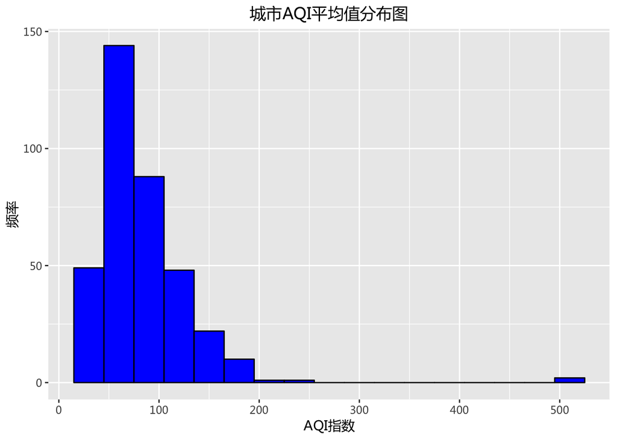

```r
plot_theme = theme(plot.title = element_text(hjust = 0.5),
              text = element_text(family = "MicrosoftYaHei"))

ggplot(avg_city_aqi, aes(城市AQI平均值)) +
  geom_histogram(color="black", fill="blue", binwidth = 30) +
  labs(title="城市AQI平均值分布图", x="AQI指数", y="频率") +
  plot_theme
```

> *有361个城市的AQI指数在15-195之间，占总体的98.9%，空气质量等级在优到轻度污染之间*
- 城市AQI平均值最低的10个城市

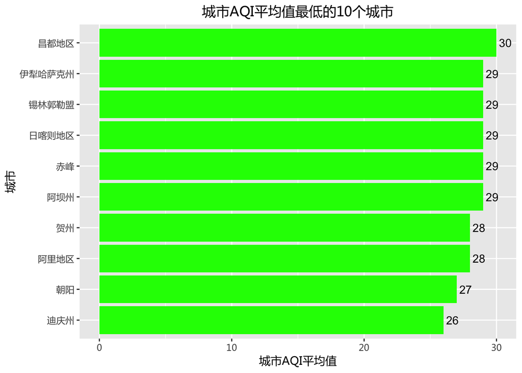

```r
avg_city_aqi %>%
  arrange(城市AQI平均值) %>%  # 按从小到大排列
  head(10) %>%  # 输出AQI平均值最低的10个城市
  # 绘制条形图
  ggplot(aes(reorder(城市, 城市AQI平均值), 城市AQI平均值)) +
  geom_bar(stat = "identity", fill = "green") +
  labs(title = "城市AQI平均值最低的10个城市", x="城市", y="城市AQI平均值") + # 标题
  geom_text(aes(label=城市AQI平均值), hjust=-0.2) + # 数据标签
  coord_flip() + # 图形转置
  plot_theme
```

- 城市AQI平均值最高的10个城市

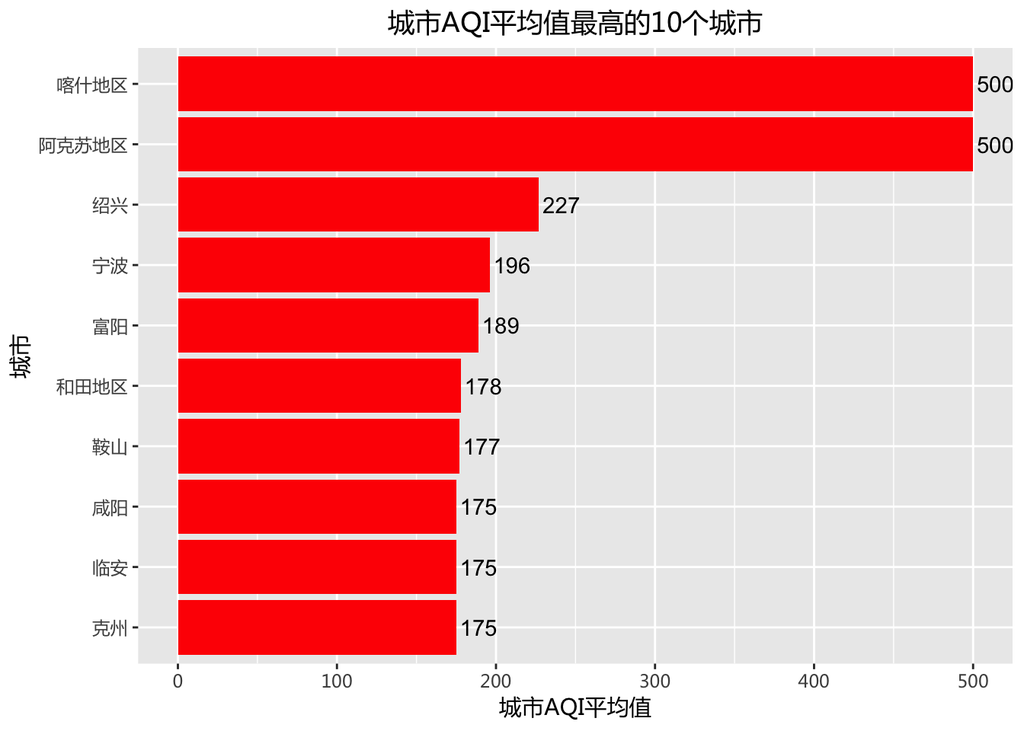

```r
avg_city_aqi %>%
  arrange(desc(城市AQI平均值)) %>%  # 按从大到小降序排列
  head(10) %>%  # 输出AQI平均值最高的10个城市
  # 绘制条形图
  ggplot(aes(reorder(城市, 城市AQI平均值), 城市AQI平均值)) +
  geom_bar(stat = "identity", fill = "red") +
  labs(title = "城市AQI平均值最高的10个城市", x="城市", y="城市AQI平均值") +
  geom_text(aes(label=城市AQI平均值), hjust=-0.1) +
  coord_flip() +
  plot_theme
```

### 4. 分析PM2.5变量

- 查看PM2.5的描述统计量

```r
describe(aqi$PM2.5)
```

```
## aqi$PM2.5
##        n  missing distinct     Info     Mean      Gmd      .05      .10
##     1453        0      161        1    57.84    38.87       13       20
##      .25      .50      .75      .90      .95
##       32       50       79      107      125
##
## lowest :   1   2   3   4   5, highest: 193 212 272 283 476
```

> *PM2.5变量有1453个值，没有缺失值，其中平均值是57.84，中位数是50，最小值是1，最大值是476*
- 按城市分组，计算各城市的PM2.5平均值

```r
avg_city_pm2.5 <- aqi %>%
  group_by(城市) %>%
  summarise(城市PM2.5平均值 = mean(PM2.5))
avg_city_pm2.5
```

| 城市 | 城市PM2.5平均值 |
| --- | --- |
| 阿坝州 | 2.666667 |
| 阿克苏地区 | 247.500000 |
| 阿拉善盟 | 23.000000 |
| 阿勒泰地区 | 16.500000 |
| 阿里地区 | 4.000000 |
| 安康 | 64.000000 |
| 安庆 | 114.500000 |
| 安顺 | 27.000000 |
| 安阳 | 75.200000 |
| 鞍山 | 134.000000 |

[output cut: 355 more lines]

- 查看城市PM2.5平均值的描述统计量

```r
summary(avg_city_pm2.5)
```

```
##      城市           城市PM2.5平均值
##  Length:365         Min.   :  2.667
##  Class :character   1st Qu.: 30.500
##  Mode  :character   Median : 47.125
##                     Mean   : 54.943
##                     3rd Qu.: 72.250
##                     Max.   :374.000
```

> *365个城市的PM2.5指数的平均值是54.94，中位数是47.13，最小值是2.67，最大值是374*
- 城市PM2.5平均值的数值分布

```r
avg_city_pm2.5 %>%
  count(PM2.5指数 = cut_width(城市PM2.5平均值, 30))
```

| PM2.5指数 | n |
| --- | --- |
| [-15,15] | 22 |
| (15,45] | 152 |
| (45,75] | 106 |
| (75,105] | 57 |
| (105,135] | 23 |
| (135,165] | 2 |
| (165,195] | 1 |
| (225,255] | 1 |
| (345,375] | 1 |

- 绘制城市PM2.5平均值的直方图

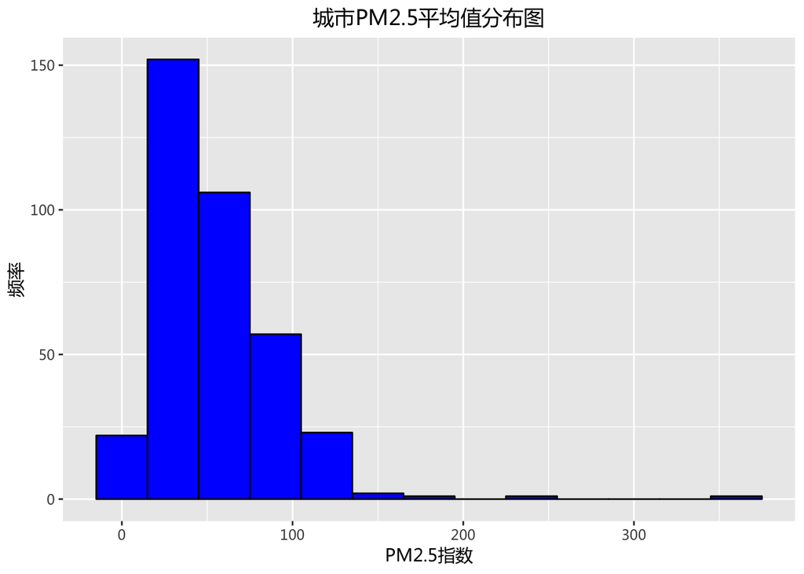

```r
ggplot(avg_city_pm2.5, aes(城市PM2.5平均值)) +
  geom_histogram(color="black", fill="blue", binwidth = 30) +
  labs(title="城市PM2.5平均值分布图", x="PM2.5指数", y="频率") +
  plot_theme
```

> *有360个城市的PM2.5指数在0-135之间，占总体的98.6%，分布与城市AQI指数基本相同，显示两者呈正相关关系*
- 城市PM2.5平均值最低的10个城市

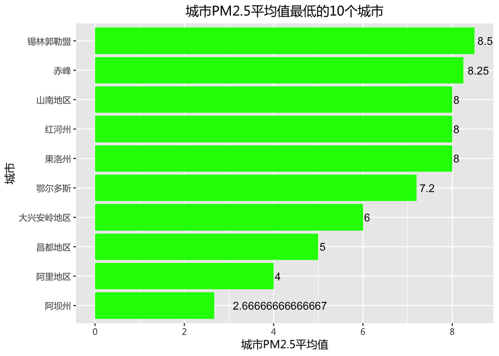

```r
avg_city_pm2.5 %>%
  arrange(城市PM2.5平均值) %>%
  head(10) %>%
  ggplot(aes(reorder(城市, 城市PM2.5平均值), 城市PM2.5平均值)) +
  geom_bar(stat = "identity", fill="green") +
  labs(title = "城市PM2.5平均值最低的10个城市", x="城市", y="城市PM2.5平均值") +
  geom_text(aes(label=城市PM2.5平均值), hjust=-0.2) +
  coord_flip() +
  plot_theme
```

- 城市PM2.5平均值最高的10个城市

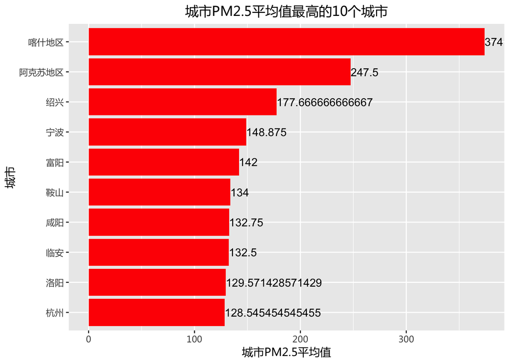

```r
avg_city_pm2.5 %>%
  arrange(desc(城市PM2.5平均值)) %>%
  head(10) %>%
  ggplot(aes(reorder(城市, 城市PM2.5平均值), 城市PM2.5平均值)) +
  geom_bar(stat = "identity", fill="red") +
  labs(title = "城市PM2.5平均值最高的10个城市", x="城市", y="城市PM2.5平均值") +
  geom_text(aes(label=城市PM2.5平均值), hjust=0) +
  coord_flip() +
  plot_theme
```

### 5. 分析PM10变量

- 查看PM10的描述统计量

```r
describe(aqi$PM10)
```

```
## aqi$PM10
##        n  missing distinct     Info     Mean      Gmd      .05      .10
##     1389       64      229        1    97.95    61.07     30.0     38.0
##      .25      .50      .75      .90      .95
##     57.0     87.0    125.0    169.2    197.0
##
## lowest :    1    5    7    8    9, highest:  386  714  801  955 1135
```

> *PM10变量有1389个值，有64个缺失值，其中平均值是97.95，中位数是87，最小值是1，最大值是1135*
- 按城市分组，计算各城市的PM10平均值

```r
avg_city_pm10 <- aqi %>%
  group_by(城市) %>%
  summarise(城市PM10平均值 = mean(PM10))
avg_city_pm10
```

| 城市 | 城市PM10平均值 |
| --- | --- |
| 阿坝州 | NA |
| 阿克苏地区 | 1045.00000 |
| 阿拉善盟 | 37.33333 |
| 阿勒泰地区 | 53.00000 |
| 阿里地区 | 8.50000 |
| 安康 | 99.33333 |
| 安庆 | 143.00000 |
| 安顺 | 40.75000 |
| 安阳 | 96.40000 |
| 鞍山 | 235.00000 |

[output cut: 355 more lines]

- 查看城市PM10平均值的描述统计量

```r
summary(avg_city_pm10)
```

```
##      城市           城市PM10平均值
##  Length:365         Min.   :   8.50
##  Class :character   1st Qu.:  59.00
##  Mode  :character   Median :  85.00
##                     Mean   :  98.81
##                     3rd Qu.: 123.45
##                     Max.   :1045.00
##                     NA's   :46
```

> *365个城市里，有46个城市没有数据，余下的319个城市里，PM10指数的平均值是98.81，中位数是85，最小值是8.5，最大值是1045*
- 城市PM10平均值的数值分布

```r
avg_city_pm10 %>%
  count(PM10指数 = cut_width(城市PM10平均值, 30))
```

| PM10指数 | n |
| --- | --- |
| [-15,15] | 1 |
| (15,45] | 38 |
| (45,75] | 96 |
| (75,105] | 74 |
| (105,135] | 48 |
| (135,165] | 28 |
| (165,195] | 22 |
| (195,225] | 5 |
| (225,255] | 2 |
| (255,285] | 1 |

[output cut: 4 more lines]

- 绘制城市PM10平均值的直方图

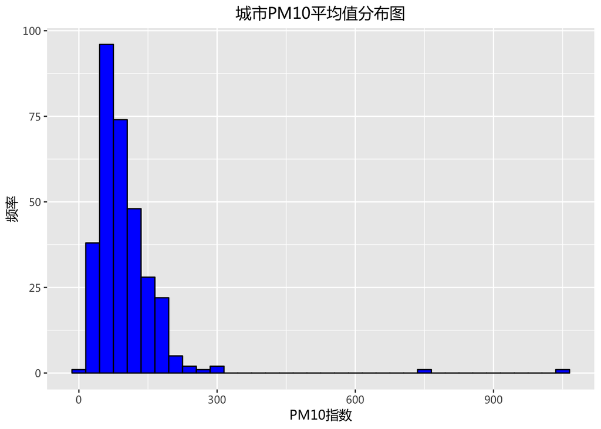

```r
ggplot(avg_city_pm10, aes(城市PM10平均值)) +
  geom_histogram(color="black", fill="blue", binwidth = 30, na.rm = TRUE) +
  labs(title = "城市PM10平均值分布图", x="PM10指数", y="频率") +
  plot_theme
```

> *有307个城市的PM10指数在0-195之间，占总体的96.2%，分布与城市AQI指数和PM2.5指数基本相同，显示三者呈现正相关关系*
- 城市PM10平均值最低的10个城市

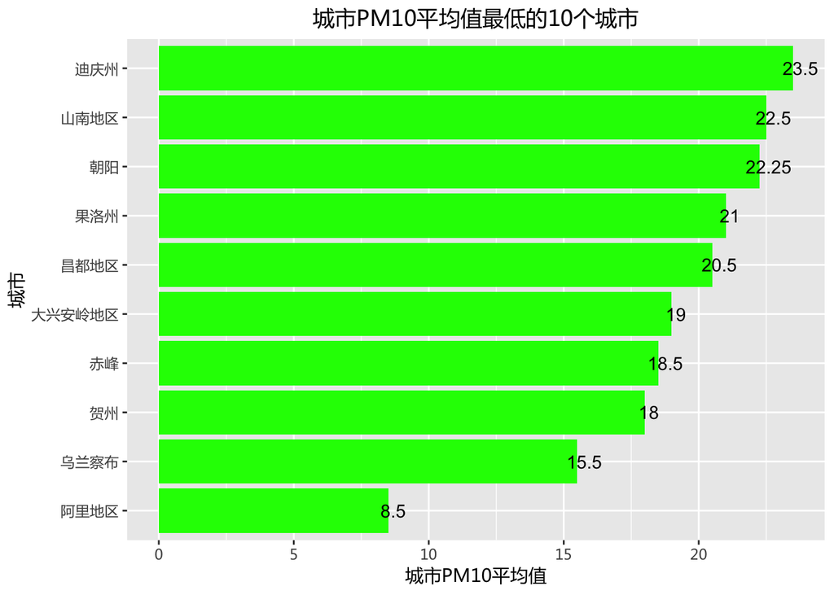

```r
avg_city_pm10 %>%
  arrange(城市PM10平均值) %>%
  head(10) %>%
  ggplot(aes(reorder(城市, 城市PM10平均值), 城市PM10平均值)) +
  geom_bar(stat = "identity", fill="green") +
  labs(title = "城市PM10平均值最低的10个城市", x="城市", y="城市PM10平均值") +
  geom_text(aes(label=城市PM10平均值), hjust=0.3) +
  coord_flip() +
  plot_theme
```

- 城市PM10平均值最高的10个城市

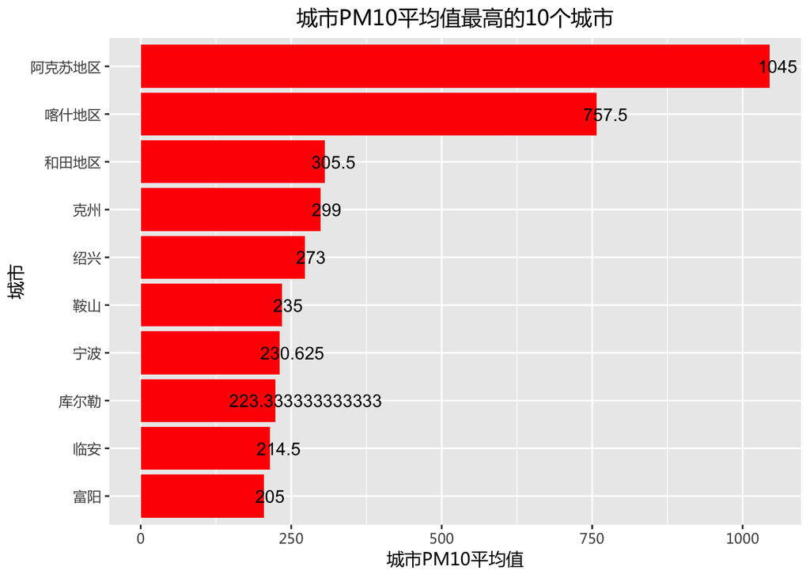

```r
avg_city_pm10 %>%
  arrange(desc(城市PM10平均值)) %>%
  head(10) %>%
  ggplot(aes(reorder(城市, 城市PM10平均值), 城市PM10平均值)) +
  geom_bar(stat = "identity", fill="red") +
  labs(title = "城市PM10平均值最高的10个城市", x="城市", y="城市PM10平均值") +
  geom_text(aes(label=城市PM10平均值), hjust=0.3) +
  coord_flip() +
  plot_theme
```

### 6. 分析首要污染物变量

- 查看首要污染物的描述统计量

```r
summary(aqi$首要污染物)
```

```
## PM2.5  <NA>  PM10    O3
##   752   257   436     8
```

- 绘制首要污染物的条形图

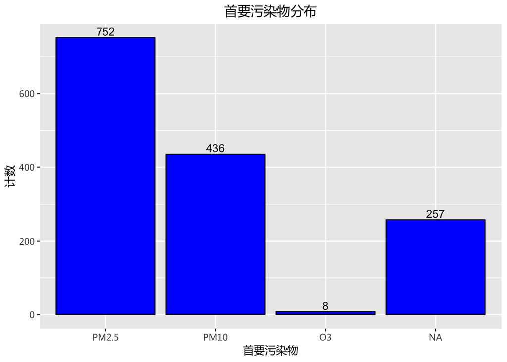

```r
ggplot(aqi, aes(aqi$首要污染物)) +
  geom_bar(color="black", fill="blue") +
  labs(title="首要污染物分布", x="首要污染物", y="计数") +
  geom_text(aes(label=as.character(..count..)), stat="count", vjust=-0.3) +
  plot_theme
```

### 7. 分析污染等级变量

- 查看污染等级的描述统计量

```r
summary(aqi$污染等级)
```

```
##       优       良 轻度污染 中度污染 严重污染
##      229      786      417       17        4
```

- 绘制污染等级的条形图

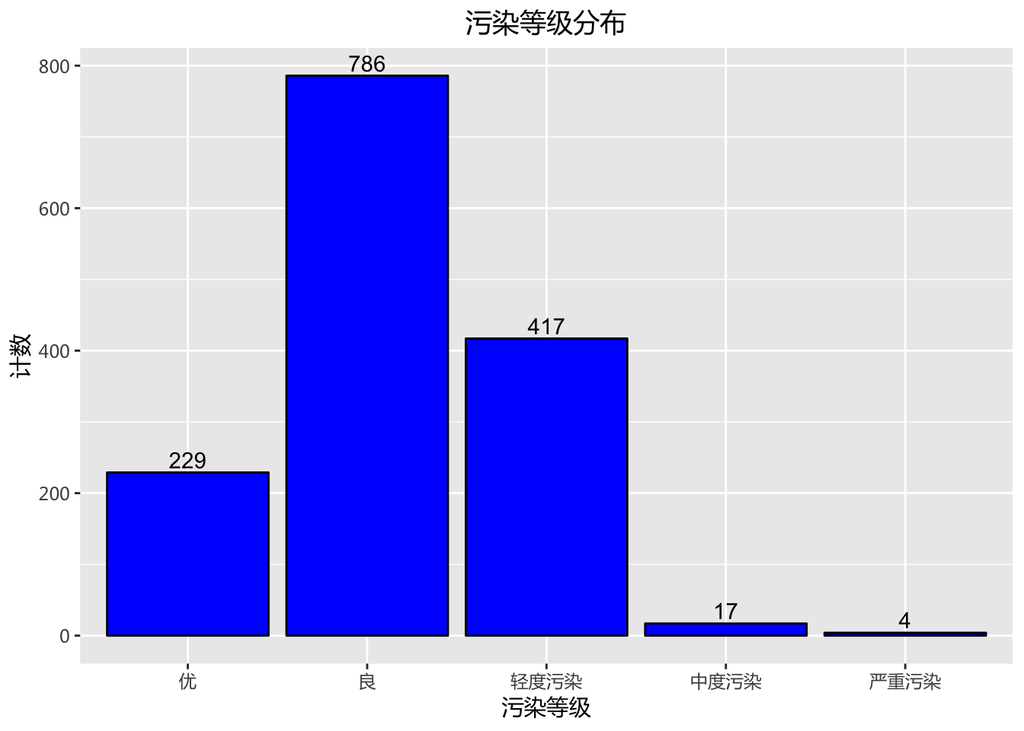

```r
ggplot(aqi, aes(aqi$污染等级)) +
  geom_bar(color="black", fill="blue") +
  labs(title = "污染等级分布", x="污染等级", y="计数") +
  geom_text(aes(label = as.character(..count..)), stat = "count", vjust=-0.3) +
  plot_theme
```

> *在污染等级中，有229个地区为优，有786个地区为良，有417个地区为轻度污染，有17个地区为中度污染，有4个地区为严重污染*

# 参考资料

1. [城市空气质量等级](https://baike.baidu.com/item/%E5%9F%8E%E5%B8%82%E7%A9%BA%E6%B0%94%E8%B4%A8%E9%87%8F%E7%AD%89%E7%BA%A7/8429673?fr=aladdin)